# Deep Neural Networks in R — Keras3 & TensorFlow for Tabular Classification

# Deep Neural Networks (DNNs) for Business Data

A feedforward network with $L$ layers has the recursive form
$$h^{(0)} = x, \quad
h^{(\ell)} = \sigma\big(W^{(\ell)} h^{(\ell-1)} + b^{(\ell)}\big),\ \ell
= 1,\dots,L-1,\quad
\hat{y} = \text{sigmoid}\big(w^{(L)} h^{(L-1)} + b^{(L)}\big)$$
where:

- $W^{(\ell)}$, $b^{(\ell)}$ are layer weights and biases.
- $\sigma(\cdot)$ is a non-linear activation (e.g. ReLU).
- The final output $\hat{y}$ is interpreted as $P(Y=1 \mid X=x)$.

Training minimizes a **loss function** plus possible regularization, e.g.
binary cross-entropy with $L_2$ penalty:
$$\mathcal{L}(\theta) = -\frac{1}{n}\sum_{i=1}^n \big[ y_i \log \hat{y}_i
+ (1-y_i)\log(1-\hat{y}_i) \big]
+ \lambda \sum_{\ell} \| W^{(\ell)} \|_2^2$$
optimized by variants of **stochastic gradient descent** (Adam, RMSprop, etc.).

In this lesson we:

We work on a tabular, business-style dataset instead of standard image benchmarks, to align with typical applied use cases.

# Step 1: Data import — Bank marketing dataset

We use a subset of the UCI Bank Marketing data (term-deposit subscription). Suppose you have saved a preprocessed version as `raw_data/bank_marketing.csv` (you can adapt the path/URL as needed).

```r
path <- "raw_data/bank_marketing.csv"

bank <- read_csv2(path, show_col_types = FALSE)
```

```
## ℹ Using "','" as decimal and "'.'" as grouping mark. Use `read_delim()` for more control.
```

```r
glimpse(bank)
```

```
## Rows: 4,521
## Columns: 17
## $ age       <dbl> 30, 33, 35, 30, 59, 35, 36, 39, 41, 43, 39, 43, 36, 20, 31, 40, 56, 37, 25, 31, 38, 42, 44, 4…
## $ job       <chr> "unemployed", "services", "management", "management", "blue-collar", "management", "self-empl…
## $ marital   <chr> "married", "married", "single", "married", "married", "single", "married", "married", "marrie…
## $ education <chr> "primary", "secondary", "tertiary", "tertiary", "secondary", "tertiary", "tertiary", "seconda…
## $ default   <chr> "no", "no", "no", "no", "no", "no", "no", "no", "no", "no", "no", "no", "no", "no", "no", "no…
## $ balance   <dbl> 1787, 4789, 1350, 1476, 0, 747, 307, 147, 221, -88, 9374, 264, 1109, 502, 360, 194, 4073, 231…
## $ housing   <chr> "no", "yes", "yes", "yes", "yes", "no", "yes", "yes", "yes", "yes", "yes", "yes", "no", "no",…
## $ loan      <chr> "no", "yes", "no", "yes", "no", "no", "no", "no", "no", "yes", "no", "no", "no", "no", "yes",…
## $ contact   <chr> "cellular", "cellular", "cellular", "unknown", "unknown", "cellular", "cellular", "cellular",…
## $ day       <dbl> 19, 11, 16, 3, 5, 23, 14, 6, 14, 17, 20, 17, 13, 30, 29, 29, 27, 20, 23, 7, 18, 19, 12, 7, 30…
## $ month     <chr> "oct", "may", "apr", "jun", "may", "feb", "may", "may", "may", "apr", "may", "apr", "aug", "a…
## $ duration  <dbl> 79, 220, 185, 199, 226, 141, 341, 151, 57, 313, 273, 113, 328, 261, 89, 189, 239, 114, 250, 1…
## $ campaign  <dbl> 1, 1, 1, 4, 1, 2, 1, 2, 2, 1, 1, 2, 2, 1, 1, 2, 5, 1, 1, 1, 2, 3, 2, 2, 3, 2, 1, 1, 2, 2, 2, …
## $ pdays     <dbl> -1, 339, 330, -1, -1, 176, 330, -1, -1, 147, -1, -1, -1, -1, 241, -1, -1, 152, -1, 152, -1, -…
## $ previous  <dbl> 0, 4, 1, 0, 0, 3, 2, 0, 0, 2, 0, 0, 0, 0, 1, 0, 0, 2, 0, 1, 0, 0, 0, 0, 0, 0, 0, 2, 0, 0, 0, …
## $ poutcome  <chr> "unknown", "failure", "failure", "unknown", "unknown", "failure", "other", "unknown", "unknow…
## $ y         <chr> "no", "no", "no", "no", "no", "no", "no", "no", "no", "no", "no", "no", "no", "yes", "no", "n…
```

Assume that:

- `y` is the target (factor with levels “no”, “yes” or 0/1).
- Other columns are numeric or categorical predictors (age, job, balance, contact metrics, etc.).

We will:

- Convert the target to a binary factor with `"no"` as reference.
- Keep a subset of useful predictors for clarity.

```r
bank <- bank |>
  mutate(
    y = factor(y, levels = c("no", "yes"))
  )

# Example: keep some core predictors (adjust to your actual columns)
bank <- bank |>
  select(
    y, age, balance, duration, campaign, pdays, previous,
    job, marital, education, default, housing, loan, contact, poutcome
  )

summary(bank$y)
```

```
##   no  yes
## 4000  521
```

# Step 2: Train/validation/test split

```r
set.seed(123)

# Create indices
n <- nrow(bank)
idx <- sample.int(n)
bank_shuffled <- bank[idx, ]

# Simple 80/10/10 split
n_train <- floor(0.8 * n)
n_valid <- floor(0.1 * n)

train <- bank_shuffled[1:n_train, ]
valid <- bank_shuffled[(n_train + 1):(n_train + n_valid), ]
test  <- bank_shuffled[(n_train + n_valid + 1):n, ]

prop.table(table(train$y))
```

```
##
##        no       yes
## 0.8855088 0.1144912
```

```r
prop.table(table(valid$y))
```

```
##
##         no        yes
## 0.90265487 0.09734513
```

```r
prop.table(table(test$y))
```

```
##
##        no       yes
## 0.8609272 0.1390728
```

# Step 3: Feature preprocessing for keras3

For tabular data with mixed types (numeric + categorical) we need to:

- Normalize numeric features.
- One-hot encode categorical features.

We build a simple preprocessing pipeline using base R; in more advanced setups you could use keras preprocessing layers or `feature_spec` utilities.

```r
num_vars <- train |>
  select(where(is.numeric)) |>
  names()

cat_vars <- train |>
  select(where(is.character) | where(is.factor)) |>
  select(-y) |>
  names()

num_vars
```

```
## [1] "age"      "balance"  "duration" "campaign" "pdays"    "previous"
```

```r
cat_vars
```

```
## [1] "job"       "marital"   "education" "default"   "housing"   "loan"      "contact"   "poutcome"
```

Standardize numeric features using training means and sds:

```r
scale_numeric <- function(df, num_vars, center, scale) {
  df |>
    mutate(across(all_of(num_vars), ~ (.x - center[cur_column()]) / scale[cur_column()]))
}

num_means <- sapply(train[, num_vars, drop = FALSE], mean, na.rm = TRUE)
num_sds   <- sapply(train[, num_vars, drop = FALSE], sd,   na.rm = TRUE)

train_scaled <- scale_numeric(train, num_vars, num_means, num_sds)
valid_scaled <- scale_numeric(valid, num_vars, num_means, num_sds)
test_scaled  <- scale_numeric(test,  num_vars, num_means, num_sds)
```

One-hot encode categorical predictors using `model.matrix()`:

```r
make_design_matrix <- function(df) {
  mm <- model.matrix(
    ~ . - 1,
    data = df |>
      select(-y) |>
      mutate(across(all_of(cat_vars), ~ factor(.x)))
  )
  as.matrix(mm)
}

X_train <- make_design_matrix(train_scaled)
X_valid <- make_design_matrix(valid_scaled)
X_test  <- make_design_matrix(test_scaled)

# Response as 0/1
y_train <- as.numeric(train_scaled$y == "yes")
y_valid <- as.numeric(valid_scaled$y == "yes")
y_test  <- as.numeric(test_scaled$y == "yes")

dim(X_train)
```

```
## [1] 3616   31
```

```r
length(y_train)
```

```
## [1] 3616
```

# Step 4: Deep network architecture — design choices

We now design a **fully connected DNN** for binary classification.

Key design components:

- **Depth and width**:
  - Start with 2–3 hidden layers (depth).
  - Number of units per layer trade off capacity and overfitting; a common heuristic is 2–4 times the input dimension or a decreasing pattern (e.g., 128 → 64 → 32).
- **Activation functions**:
  - Hidden layers: ReLU (or variants) to avoid vanishing gradients.
  - Output layer: sigmoid for binary classification.
- **Loss and optimization**:
  - Binary cross-entropy loss.
  - Adam optimizer with a moderate learning rate (e.g., 1e-3).
- **Regularization**:
  - L2 weight decay on dense layers.
  - Dropout layers between dense layers (e.g., dropout rate 0.3–0.5).
- **Validation and early stopping**:
  - Monitor validation loss.
  - Use `EarlyStopping` callback with patience to stop training when performance stops improving.

Mathematically, each hidden layer is
$$h^{(\ell)} = \max(0, W^{(\ell)} h^{(\ell-1)} + b^{(\ell)}),$$
and dropout randomly sets a fraction $p$ of units to zero during training, approximating an ensemble of thinned networks and acting as a regularizer.

# Step 5: Implement the model in keras3

```r
input_dim <- ncol(X_train)
input_dim
```

```
## [1] 31
```

Define the model:

```r
library(keras3)

build_dnn_model <- function(input_dim, l2_lambda = 1e-4, dropout_rate = 0.3) {

  input <- layer_input(shape = input_dim, name = "features")

  x <- input |>
    layer_dense(units = 128, activation = "relu",
                kernel_regularizer = regularizer_l2(l = l2_lambda)) |>
    layer_dropout(rate = dropout_rate) |>
    layer_dense(units = 64, activation = "relu",
                kernel_regularizer = regularizer_l2(l = l2_lambda)) |>
    layer_dropout(rate = dropout_rate) |>
    layer_dense(units = 32, activation = "relu",
                kernel_regularizer = regularizer_l2(l = l2_lambda))

  output <- x |>
    layer_dense(units = 1, activation = "sigmoid", name = "output")

  model <- keras_model(inputs = input, outputs = output)

  model |>
    compile(
      optimizer = optimizer_adam(learning_rate = 1e-3),
      loss = "binary_crossentropy",
      metrics = list(
        "accuracy",
        metric_precision(name = "precision"),
        metric_recall(name = "recall")
      )
    )

  model
}

model <- build_dnn_model(input_dim)
model
```

```
## Model: "functional_11"
## ┏━━━━━━━━━━━━━━━━━━━━━━━━━━━━━━━━━━━━━━━━━━━━━━━━━┳━━━━━━━━━━━━━━━━━━━━━━━━━━━━━━━━━━━━━━┳━━━━━━━━━━━━━━━━━━━━━━┓
## ┃ Layer (type)                                    ┃ Output Shape                         ┃              Param # ┃
## ┡━━━━━━━━━━━━━━━━━━━━━━━━━━━━━━━━━━━━━━━━━━━━━━━━━╇━━━━━━━━━━━━━━━━━━━━━━━━━━━━━━━━━━━━━━╇━━━━━━━━━━━━━━━━━━━━━━┩
## │ features (InputLayer)                           │ (None, 31)                           │                    0 │
## ├─────────────────────────────────────────────────┼──────────────────────────────────────┼──────────────────────┤
## │ dense_17 (Dense)                                │ (None, 128)                          │                4,096 │
## ├─────────────────────────────────────────────────┼──────────────────────────────────────┼──────────────────────┤
## │ dropout_8 (Dropout)                             │ (None, 128)                          │                    0 │
## ├─────────────────────────────────────────────────┼──────────────────────────────────────┼──────────────────────┤
## │ dense_18 (Dense)                                │ (None, 64)                           │                8,256 │
## ├─────────────────────────────────────────────────┼──────────────────────────────────────┼──────────────────────┤
## │ dropout_9 (Dropout)                             │ (None, 64)                           │                    0 │
## ├─────────────────────────────────────────────────┼──────────────────────────────────────┼──────────────────────┤
## │ dense_19 (Dense)                                │ (None, 32)                           │                2,080 │
## ├─────────────────────────────────────────────────┼──────────────────────────────────────┼──────────────────────┤
## │ output (Dense)                                  │ (None, 1)                            │                   33 │
## └─────────────────────────────────────────────────┴──────────────────────────────────────┴──────────────────────┘
##  Total params: 14,465 (56.50 KB)
##  Trainable params: 14,465 (56.50 KB)
##  Non-trainable params: 0 (0.00 B)
```

# Step 6: Train with validation and early stopping

```r
callback_es <- callback_early_stopping(
  monitor = "val_loss",
  patience = 10,
  restore_best_weights = TRUE
)

set.seed(123)
history <- model |>
  fit(
    x = X_train, y = y_train,
    validation_data = list(X_valid, y_valid),
    epochs = 200,
    batch_size = 256,
    callbacks = list(callback_es),
    verbose = 2
  )
```

Plot training curves:

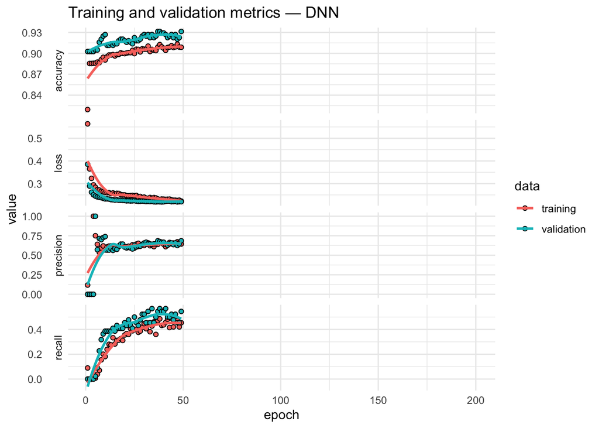

```r
plot(history) +
  theme_minimal() +
  ggtitle("Training and validation metrics — DNN")
```

Points to discuss:

- Diverging training/validation curves indicate overfitting.
- Early stopping truncates training once validation loss stops decreasing, selecting a model near the low point of validation loss.

# Step 7: Evaluation on test set

```r
metrics_test <- model |>
  evaluate(X_test, y_test, verbose = 0)

metrics_test
```

```
## $accuracy
## [1] 0.8830022
##
## $loss
## [1] 0.2930982
##
## $precision
## [1] 0.6190476
##
## $recall
## [1] 0.4126984
```

For a clearer view:

```r
named_metrics <- setNames(as.numeric(metrics_test), names(metrics_test))
round(named_metrics, 3)
```

```
##  accuracy      loss precision    recall
##     0.883     0.293     0.619     0.413
```

We can also inspect the confusion matrix at threshold 0.5:

```r
pred_prob <- model |> predict(X_test)
pred_class <- ifelse(pred_prob >= 0.5, 1, 0)

table(
  truth = factor(y_test, levels = c(0, 1), labels = c("no", "yes")),
  pred  = factor(pred_class, levels = c(0, 1), labels = c("no", "yes"))
)
```

```
##      pred
## truth  no yes
##   no  374  16
##   yes  37  26
```

Consider reporting accuracy, precision, recall, and F1; in marketing applications, recall for the positive class (“yes”) is often a key metric.

# Step 8: Architecture sensitivity — width, depth, and regularization

You can quickly study architectural variations:

- More or fewer layers.
- Larger or smaller units.
- Stronger or weaker L2 and dropout.

Example: a **shallower model** without strong regularization:

```r
model_shallow <- keras_model_sequential() |>
  layer_dense(
    units = 32, activation = "relu", input_shape = input_dim
  ) |>
  layer_dense(units = 1, activation = "sigmoid")

model_shallow |>
  compile(
    optimizer = optimizer_adam(learning_rate = 1e-3),
    loss = "binary_crossentropy",
    metrics = "accuracy"
  )

history_shallow <- model_shallow |>
  fit(
    X_train, y_train,
    validation_data = list(X_valid, y_valid),
    epochs = 200,
    batch_size = 256,
    callbacks = list(callback_es),
    verbose = 0
  )

metrics_shallow <- model_shallow |>
  evaluate(X_test, y_test, verbose = 0)

c(
  DNN_regularized = round(named_metrics["accuracy"], 3),
  Shallow         = round(as.numeric(metrics_shallow["accuracy"]), 3)
)
```

```
## DNN_regularized.accuracy                  Shallow
##                    0.883                    0.574
```

Discussion:

- If the shallow model underperforms, the deeper network is exploiting additional representation power.
- If the deeper model overfits while the shallow model generalizes better, you may need more regularization or simpler architectures.

# Step 9: Practical considerations

Some key best practices when deploying DNNs for tabular business data:

- **Normalization**: Always normalize numeric features; DNNs are sensitive to scale.
- **Class imbalance**: Use class weights or focal losses when the positive class is rare.
- **Regularization**:
  - L2 weight decay to penalize large weights.
  - Dropout between dense layers to mitigate co-adaptation.
- **Validation strategy**:
  - Keep a validation set that mirrors the operational distribution.
  - Use early stopping to prevent overfitting.
- **Reproducibility**:
  - Fix seeds (R + Python) when possible.
  - Log architectures, hyperparameters, and performance.

# Summary

In this lesson you learned how to:

- Formulate a deep neural network as a composition of affine maps and non-linear activations, trained by minimizing cross-entropy with regularization.
- Design a DNN architecture for tabular business data, selecting depth, width, activations, and regularization (dropout, L2).
- Implement the model in R with keras3 and TensorFlow, including data preprocessing, training with validation and early stopping, and evaluation on a held-out test set.
- Compare alternative architectures and interpret their impact on generalization.

A work by [Gianluca Sottile](https://www.unipa.it/persone/docenti/s/gianluca.sottile)

*gianluca.sottile@unipa.it*